# Heat Flow Near Arcs

Spatial Continuity and Sampling Strategies

Buchanan Kerswell

12/15/2020

# Shameless Plug

I am defending a PhD in 2021 and looking for a job. If you are hiring a post-doc, I would love to work with you! If you know of another position, please let me know.

Check out my website. There you can find my resume and learn more about me.

[My Website](https://buchanankerswell.com) [My Resume](https://buchanankerswell.com/resume.html)

Enjoy this short presentation. :)

# Introduction

Subduction zones are recognized as important features of an active planet. Foundering oceanic lithosphere drives opening and closing of ocean basins (Wilson, 1966), orogenesis, arc volcanism, deadly megathrust earthquakes, and is the primary mechanism for planet-scale chemical differentiation (Grove et al., 2009; Hacker et al., 2003; McKenzie, 1969; S. A. Peacock, 1990; S. M. Peacock, 1996). However, these processes operate at depths of 10$^1$ to 10$^2$ kilometers and at rates of a few cm/year. To understand subduction, we must rely on seismic imaging of modern subduction zones (Currie & Hyndman, 2006; Engdahl et al., 1998), records of ancient subduction zones preserved in exhumed rocks (Agard et al., 2009; Penniston-Dorland et al., 2015), and numerical models (e.g., Gerya et al., 2008). With the exception of numerical models, these datasets are expensive to collect, sparse, discontinuous across time and space, and layered with complexity.

Previous work demonstrates how strengths of brittle faults (Gao & Wang, 2014), depths of seismic and mechanical coupling (Furukawa, 1993; Kerswell et al., 2020; Wada & Wang, 2009), and thermal structure of subduction zones (Currie & Hyndman, 2006) can be inverted from surface heat flow (e.g. Figure 1). This study focused on analyzing the spatial distribution and continuity of the heat flow near arcs to assess the reliability of inversion techniques. We sampled the global heat flow database (Lucazeau, 2019) within 1000 km of thirteen arc segments and used kriging to provide a continuous estimation of heat flow. The kriged results show that previous sampling methods may have overestimated the spatial continuity of heat flow near arcs. We caution against extrapolation of surface heat flow inversions within, and among arc segments. Inferences derived from paterns of heat flow should be considered representative of local phenomenon only.

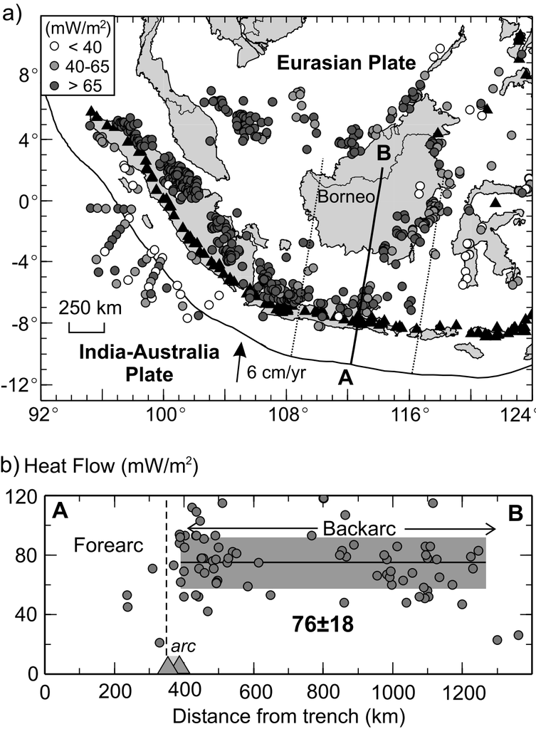

Figure 1. Sampling surface heat flow along a transect perpendicular to the Sumatra arc segment. Consistently high heat flow in the backarc is interpreted to represent a thin (warm) backarc lithosphere. From Currie & Hyndman (2006).

# Methods

The global heat flow dataset contains over 60000 individual terrestrial and marine heat flow measurements (Lucazeau, 2019). The dataset can be downloaded from the International Heat Flow Commission’s [website](http://ihfc-iugg.org/). The database is under revision and currently has no quality control.

1. Negative thermal gradients
2. Heat flow below 10 $mW/m^2$
3. Heat flow above 120 $mW/m^2$
4. Thermal gradients above 500 $mK/m$

Table 1. Filtered heat flow measurements within 1000 km of arc segments

| segment | n |
| --- | --- |
| Kamchatka Marianas | 824 |
| Kyushu Ryukyu | 499 |
| Sumatra Banda Sea | 446 |
| Central America | 303 |
| Andes | 237 |
| Tonga New Zealand | 226 |
| N. Philippines | 143 |
| S. Philippines | 105 |
| New Britain Solomon | 73 |
| Lesser Antilles | 68 |
| Alaska Aleutians | 66 |
| Vanuatu | 21 |
| Scotia | 11 |

Our filtering scheme follows Currie & Hyndman (2006). We attempted basic quality control and removal of measurements that represent circulation of seawater within seafloor sediments and crust. Our goal was to “see through” near-surface processes that would obfuscate direct correspondence between surface heat flow and subduction zone thermal structure. A summary of the filtered dataset is given in Table 1 and Figure 3.

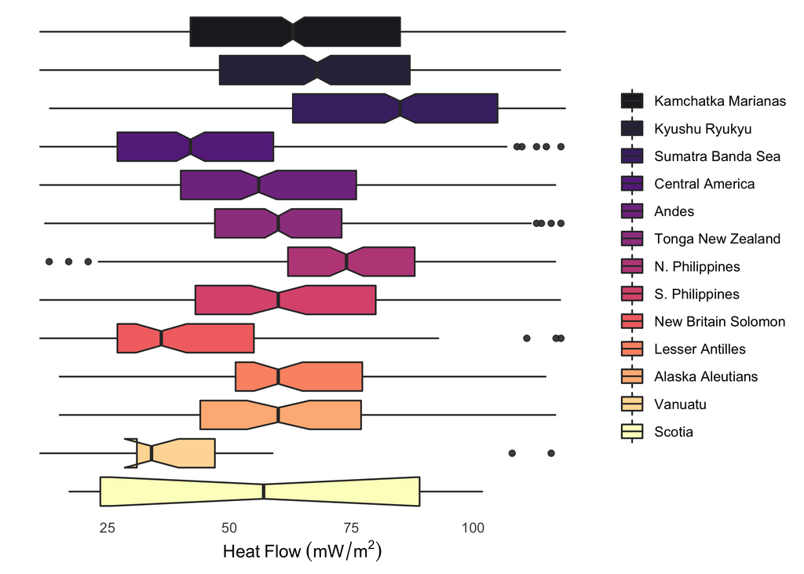

Figure 3. Filtered heat flow data within 1000 km of arc segments. The data are broadly distributed within, and among, arc segments.

Experimental variograms, variogram model fitting, kriging, and interpolation were achieved with a one-line function (see Appendix) that wraps functions from the R `geostat` package (Gräler et al., 2016; Pebesma, 2004). One-hundred lags were used to capture the variability in the experimental variogram and spherical variogram models were fit in all cases. Segments with median number of point-pairs less than thirty were not included in the analysis. Ordinary kriging and a inverse distance weighted scheme was used for interpolation.

# Results

Seven out of thirteen arc segments have sufficient heat flow data to calculate experimental variograms with a median number of point-pairs greater than thirty (Table 2).

Table 2. Summary of point-pairs in experimental variograms

| segment | np.max | np.min | np.mean | np.median |
| --- | --- | --- | --- | --- |
| Kamchatka Marianas | 9134 | 1153 | 2207 | 1922 |
| Kyushu Ryukyu | 1553 | 269 | 665 | 608 |
| Sumatra Banda Sea | 1078 | 354 | 606 | 587 |
| Central America | 935 | 124 | 334 | 302 |
| Andes | 831 | 46 | 160 | 134 |
| Tonga New Zealand | 522 | 1 | 181 | 106 |
| N. Philippines | 168 | 17 | 61 | 46 |
| S. Philippines | 100 | 11 | 29 | 26 |
| Alaska Aleutians | 33 | 3 | 12 | 11 |
| Lesser Antilles | 24 | 1 | 11 | 10 |
| New Britain Solomon | 102 | 1 | 18 | 8 |
| Scotia | 2 | 1 | 1 | 1 |
| Vanuatu | 4 | 1 | 2 | 1 |

Experimental variograms with less than thirty point pairs per lag are suspect, so only Kamchatka-Marianas, Kyushu-Ryukyu, Sumatra-Banda Sea, Tonga-New Zealand, N. Philippines, Andes, and Central America are considered in the Kriging analysis. Five are presented below for brevity.

Table 3. Summary of modelled variogram parameter estimates

| segment | nugget | sill | range |
| --- | --- | --- | --- |
| Kamchatka Marianas | 497 | 752 | 51 |
| Kyushu Ryukyu | 376 | 545 | 6 |
| Sumatra Banda Sea | 89 | 987 | 1707 |
| Central America | 53 | 435 | 36 |
| Andes | 189 | 766 | 29 |
| Tonga New Zealand | 376 | 1638 | 4734 |
| N. Philippines | 9 | 138 | 16 |

The modelled variogram parameter estimates vary from segment to segment (Table 3 & Figure 4). The modelled variogram ranges range from <10$^1$ km (Kyushu-Ryukyu) to >10$^2$ km. The range in nuggets and sills is less important for assessing spatial correlation, but also range widely from segment to segment.

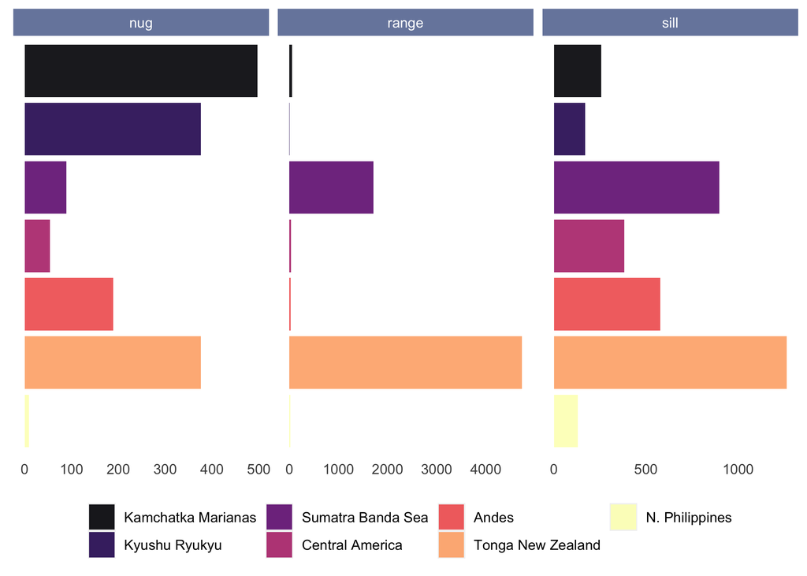

Figure 4. Modelled variogram parameter estimates. Huge variability in the ranges among segment is difficult to interpret, but indicates a wide range of spatial continuity with respect to surface heat flow.

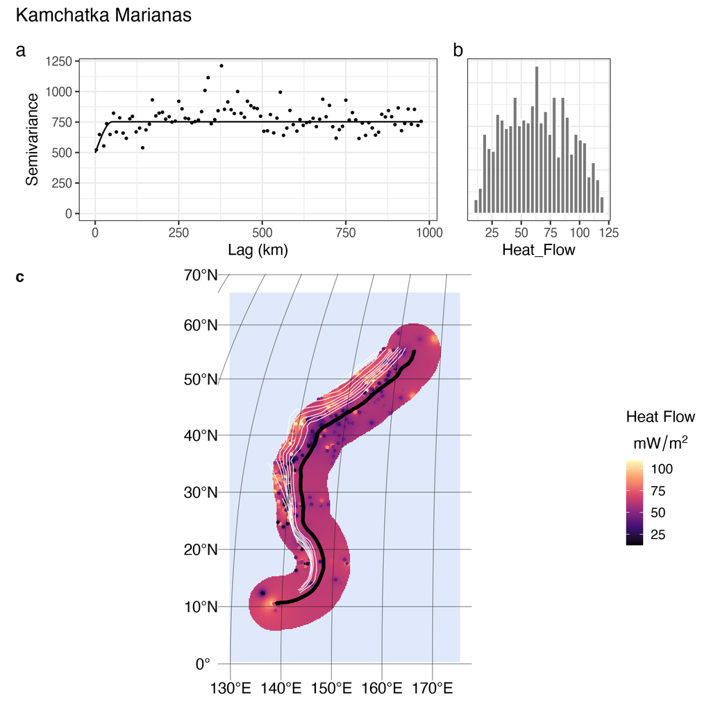

Figure 5. Kriging results for Kamchatka-Marianas. a) The experimental (dots) and modelled (line) variograms. A spherical variogram model is used with parameters given in Table 3. The narrow modelled variogram range indicates low spatial correlation, except for points spaced less than ~51 km apart. b) Histogram shows an approximately normal distribution, but gives no spatial context. c) Interpolated heat flow generally conforms to the expectation of low heat flow in the forearc and high heat flow near the arc and into the backarc.

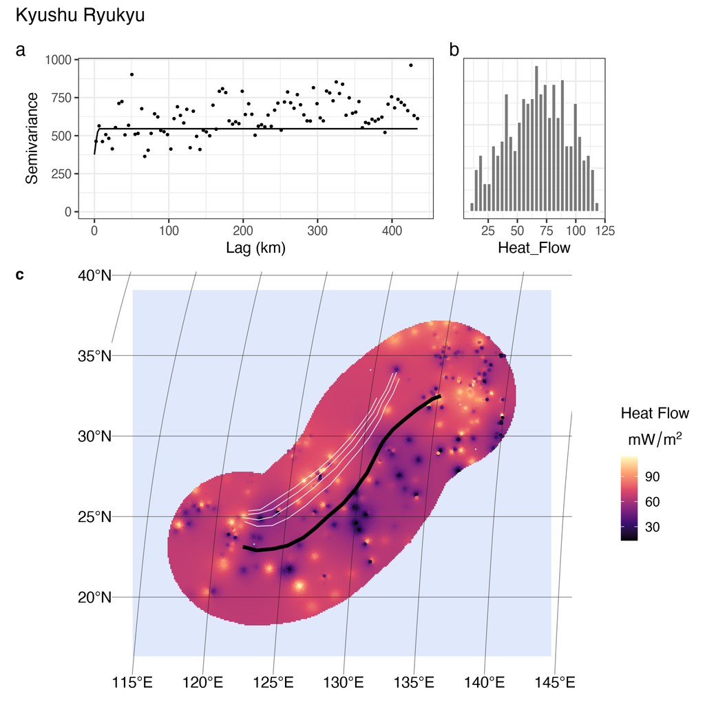

Figure 6. Kriging results for Kyushu-Ryukyu. a) The experimental (dots) and modelled (line) variograms. A spherical variogram model is used with parameters given in Table 3. The narrow modelled variogram range indicates low spatial correlation, except for points spaced less than ~6 km apart. b) Histogram shows an approximately normal distribution, but gives no spatial context. c) Interpolated heat flow shows a quasi-random distribution.

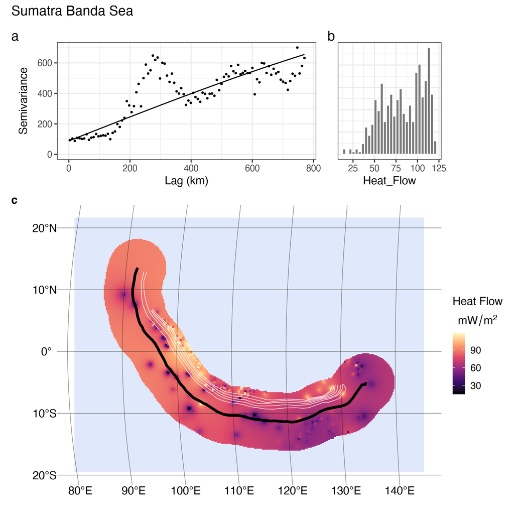

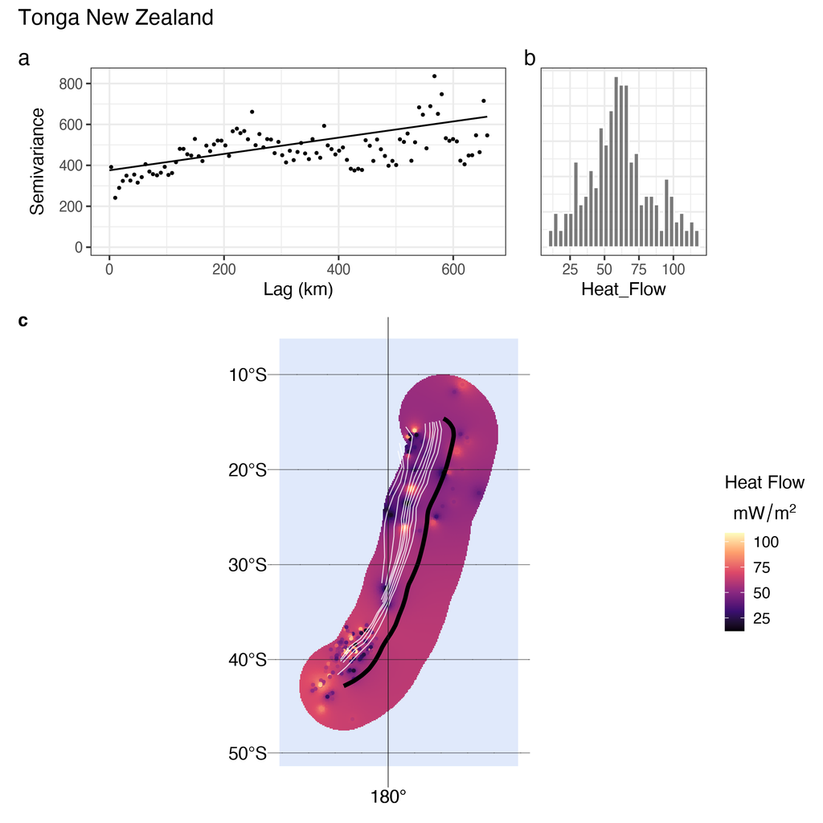

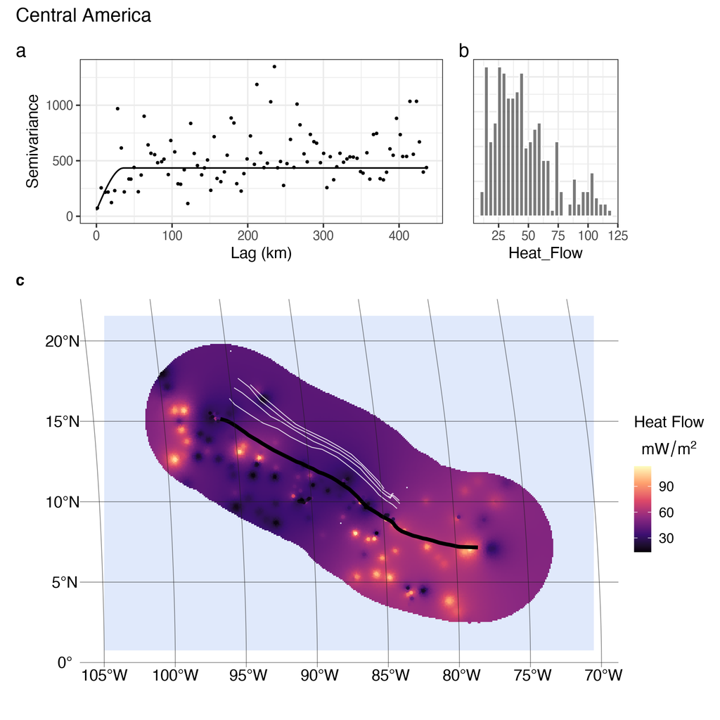

# Discussion

# Conclusion

Much has been inferred about seismic and geodynamic processes in subduction zones by inverting surface heat flow (Currie & Hyndman, 2006; Furukawa, 1993; Gao & Wang, 2014; Kerswell et al., 2020; Wada & Wang, 2009). However, the kriging analysis presented here indicates that methods of sampling and averaging surface heat flow along individual segments is not a robust method for investigating potential commonalities within, or among, arc segments. Rather, the interpolated distribution of heat flow near arcs indicates that the thermal structure and seismic activities near arcs is less spatially continuous than previously thought, surface heat flow signals are too mixed or too obfuscated to interpret, not enough data exists to make broad claims about subduction zones, or any combination of the above. Future work may consider more local phenomena from surface heat flow inversions, or focus on increasing the spatial coverage of the currently available dataset.

# Appendix

## Functions

### Kriging

```r
# Kriging
krg <- function(data, lags = 50, lag.cutoff = 5, param, krg.shp, seg, contours, crs, ngrid = 3e5, grid.method = 'hexagonal', v.mod = 'Sph'){
  d <- data
  cutoff <- max(st_distance(data))/lag.cutoff %>% as.numeric()
  class(cutoff) <- 'numeric'
  b <- krg.shp
  s <- b %>% st_sample(size = ngrid, grid.method)
  v <- variogram(get(param)~1, locations = d, cutoff = cutoff, width = cutoff/lags)
  f <- fit.variogram(v, vgm(NA, 'Sph', NA, NA))
  v.m <- variogramLine(f, maxdist = max(v$dist))
  k <- krige(formula = get(param)~1, locations = d, newdata = s) %>% select(-var1.var)
  return(list(variogram = v, v.model = f, krg = k))
}
```

# Shameless Plug

I hope you enjoyed the pretty pictures

I am defending a PhD in 2021 and looking for a job. If you are hiring a post-doc, I would love to work with you! If you know of another position, please let me know.

Check out my website. There you can find my resume and learn more about me.

[My Website](https://buchanankerswell.com) [My Resume](https://buchanankerswell.com/resume.html)

# References

Agard, P., Yamato, P., Jolivet, L., & Burov, E. (2009). Exhumation of oceanic blueschists and eclogites in subduction zones: Timing and mechanisms. *Earth-Science Reviews*, *92*(1-2), 53–79.

Currie, C. A., & Hyndman, R. D. (2006). The thermal structure of subduction zone back arcs. *Journal of Geophysical Research: Solid Earth*, *111*(B8).

Engdahl, E. R., Hilst, R. van der, & Buland, R. (1998). Global teleseismic earthquake relocation with improved travel times and procedures for depth determination. *Bulletin of the Seismological Society of America*, *88*(3), 722–743.

Furukawa, Y. (1993). Depth of the decoupling plate interface and thermal structure under arcs. *Journal of Geophysical Research: Solid Earth*, *98*(B11), 20005–20013.

Gao, X., & Wang, K. (2014). Strength of stick-slip and creeping subduction megathrusts from heat flow observations. *Science*, *345*(6200), 1038–1041.

Gerya, T. V., Connolly, J. A., & Yuen, D. A. (2008). Why is terrestrial subduction one-sided? *Geology*, *36*(1), 43–46.

Gräler, B., Pebesma, E., & Heuvelink, G. (2016). Spatio-temporal interpolation using gstat. *The R Journal*, *8*, 204–218. Retrieved from https://journal.r-project.org/archive/2016/RJ-2016-014/index.html

Grove, T., Till, C., Lev, E., Chatterjee, N., & Médard, E. (2009). Kinematic variables and water transport control the formation and location of arc volcanoes. *Nature*, *459*(7247), 694–697.

Hacker, B. R., Abers, G. A., & Peacock, S. M. (2003). Subduction factory 1. Theoretical mineralogy, densities, seismic wave speeds, and H2O contents. *Journal of Geophysical Research: Solid Earth*, *108*(B1).

Kerswell, B. C., Kohn, M. J., & Gerya, T. V. (2020). Backarc lithospheric thickness and serpentine stability control slab-mantle coupling depths in subduction zones. *Earth and Space Science Open Archive*, 34. https://doi.org/10.1002/essoar.10503710.1

Lucazeau, F. (2019). Analysis and mapping of an updated terrestrial heat flow data set. *Geochemistry, Geophysics, Geosystems*, *20*(8), 4001–4024.

McKenzie, D. P. (1969). Speculations on the consequences and causes of plate motions. *Geophysical Journal International*, *18*(1), 1–32.

Peacock, S. A. (1990). Fluid processes in subduction zones. *Science*, *248*(4953), 329–337.

Peacock, S. M. (1996). Thermal and petrologic structure of subduction zones. *Subduction: Top to Bottom*, *96*, 119–133.

Pebesma, E. J. (2004). Multivariable geostatistics in S: The gstat package. *Computers & Geosciences*, *30*, 683–691.

Penniston-Dorland, S. C., Kohn, M. J., & Manning, C. E. (2015). The global range of subduction zone thermal structures from exhumed blueschists and eclogites: Rocks are hotter than models. *Earth and Planetary Science Letters*, *428*, 243–254.

Syracuse, E. M., & Abers, G. A. (2006). Global compilation of variations in slab depth beneath arc volcanoes and implications. *Geochemistry, Geophysics, Geosystems*, *7*(5).

Wada, I., & Wang, K. (2009). Common depth of slab-mantle decoupling: Reconciling diversity and uniformity of subduction zones. *Geochemistry, Geophysics, Geosystems*, *10*(10).

Wilson, J. T. (1966). Did the atlantic close and then re-open? *Nature*, *211*(5050), 676–681.